# R_Final_Project

Mauricio Sanchez

November 29, 2015

# R Bridge –Final Project

Objective: To analyze a subset of the hflights data to draw a parallel between airlines that have the least and the most delays. This will help one make an intelligent decision when choosing airlines flying out of Houston airports.

# 1

Invoke the hflights package and display the head data of the entire data set.

```r
require (hflights);
```

```r
require(ggplot2);
require(sqldf);
warning(FALSE);
```

# 2

Format Date

```r
formatdate <- paste(hflights$Month, hflights$DayofMonth, hflights$Year, sep="-");
hflights$Date <- formatdate;
hflights$Date <- as.Date(formatdate, "%m-%d-%Y");
```

# 3

Translate Week Days

```r
hflights$DayOfWeek <- sub(1, 'Monday', hflights$DayOfWeek)
hflights$DayOfWeek <- sub(2, 'Tuesday', hflights$DayOfWeek)
hflights$DayOfWeek <- sub(3, 'Wednesday', hflights$DayOfWeek)
hflights$DayOfWeek <- sub(4, 'Thursday', hflights$DayOfWeek)
hflights$DayOfWeek <- sub(5, 'Friday', hflights$DayOfWeek)
hflights$DayOfWeek <- sub(6, 'Saturday', hflights$DayOfWeek)
hflights$DayOfWeek <- sub(7, 'Sunday', hflights$DayOfWeek)
```

# 3

Quick Snapshot of the Data

```r
head(hflights);
```

```
##      Year Month DayofMonth DayOfWeek DepTime ArrTime UniqueCarrier
## 5424 2011     1          1  Saturday    1400    1500            AA
## 5425 2011     1          2    Sunday    1401    1501            AA
## 5426 2011     1          3    Monday    1352    1502            AA
## 5427 2011     1          4   Tuesday    1403    1513            AA
## 5428 2011     1          5 Wednesday    1405    1507            AA
## 5429 2011     1          6  Thursday    1359    1503            AA
##      FlightNum TailNum ActualElapsedTime AirTime ArrDelay DepDelay Origin
## 5424       428  N576AA                60      40      -10        0    IAH
## 5425       428  N557AA                60      45       -9        1    IAH
## 5426       428  N541AA                70      48       -8       -8    IAH
## 5427       428  N403AA                70      39        3        3    IAH
## 5428       428  N492AA                62      44       -3        5    IAH
## 5429       428  N262AA                64      45       -7       -1    IAH
##      Dest Distance TaxiIn TaxiOut Cancelled CancellationCode Diverted
## 5424  DFW      224      7      13         0                         0
## 5425  DFW      224      6       9         0                         0
## 5426  DFW      224      5      17         0                         0
## 5427  DFW      224      9      22         0                         0
## 5428  DFW      224      9       9         0                         0
## 5429  DFW      224      6      13         0                         0
##            Date
## 5424 2011-01-01
## 5425 2011-01-02
## 5426 2011-01-03
## 5427 2011-01-04
## 5428 2011-01-05
## 5429 2011-01-06
```

# 4

Choose a subset of the data.

```r
dd1 <- sqldf("SELECT UniqueCarrier, COUNT(ArrDelay) AS ArrivalDelays FROM hflights WHERE ArrDelay > 0 GROUP BY UniqueCarrier ORDER BY 2 DESC");
dd2 <- sqldf("SELECT UniqueCarrier, COUNT(Distance) AS Flights FROM hflights WHERE Distance > 0 GROUP BY UniqueCarrier ORDER BY UniqueCarrier ASC");
dd3 <- merge(dd1, dd2, by="UniqueCarrier");
dd3["Ratio"] <- round(((dd3$ArrivalDelays/dd3$Flights)*100), digits=0);
```

# 5

Show Arrival Delays by Airline.

```r
print(dd3);
```

```
##    UniqueCarrier ArrivalDelays Flights Ratio
## 1             AA           963    3244    30
## 2             AS           159     365    44
## 3             B6           266     695    38
## 4             CO         34044   70032    49
## 5             DL          1003    2641    38
## 6             EV           780    2204    35
## 7             F9           463     838    55
## 8             FL           657    2139    31
## 9             MQ          1665    4648    36
## 10            OO          8443   16061    53
## 11            UA          1009    2072    49
## 12            US          1317    4082    32
## 13            WN         20685   45343    46
## 14            XE         35429   73053    48
## 15            YV            37      79    47
```

# 6

The airline with the highest ratio of arrival delays is Frontier Flight (F9) with a 55 percent delay ratio. The airline with the lowest arrival delays is American Airlines (AA) with 30 percent.

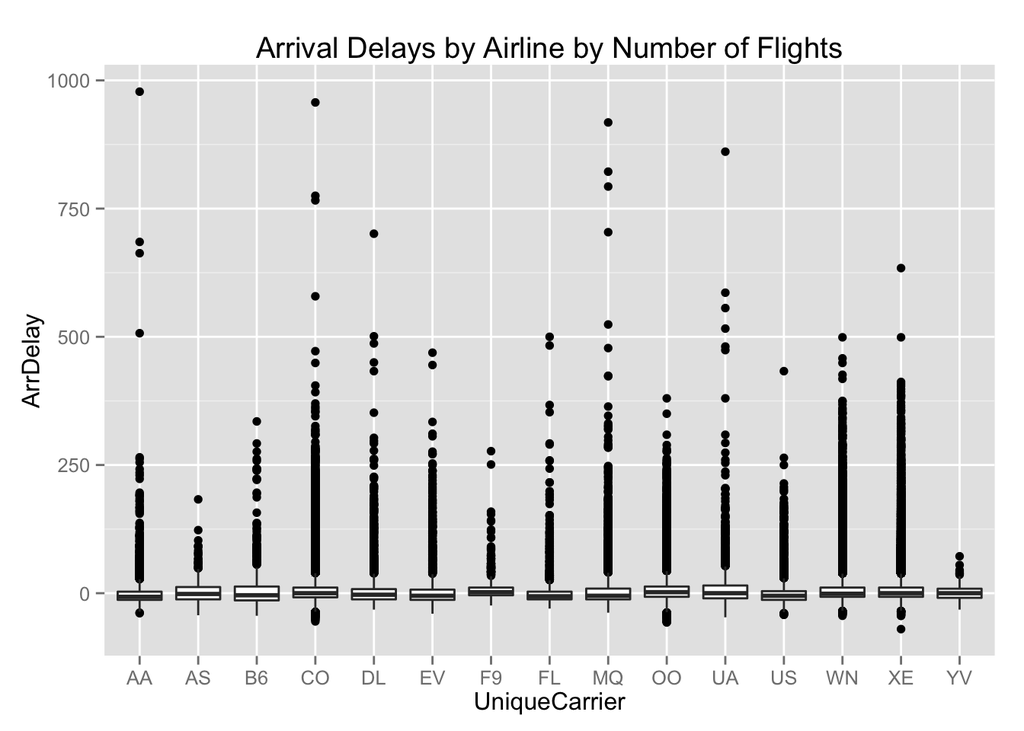

```r
ggplot(hflights, aes(x = UniqueCarrier, y = ArrDelay)) + geom_boxplot() + ggtitle("Arrival Delays by Airline by Number of Flights");
```

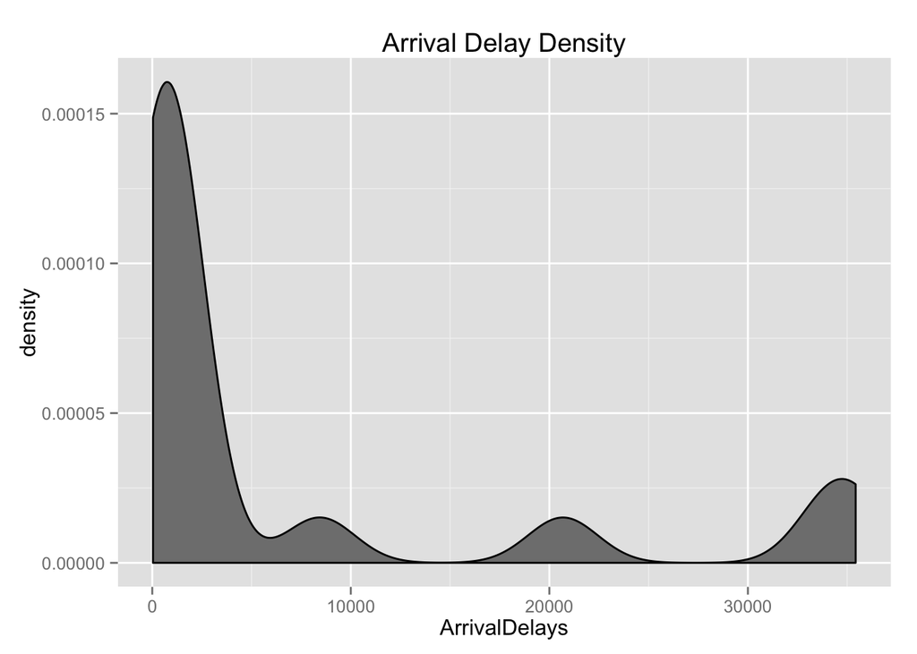

```r
ggplot(data = dd3) + geom_density(aes(x=ArrivalDelays), fill="grey50") + ggtitle("Arrival Delay Density");
```

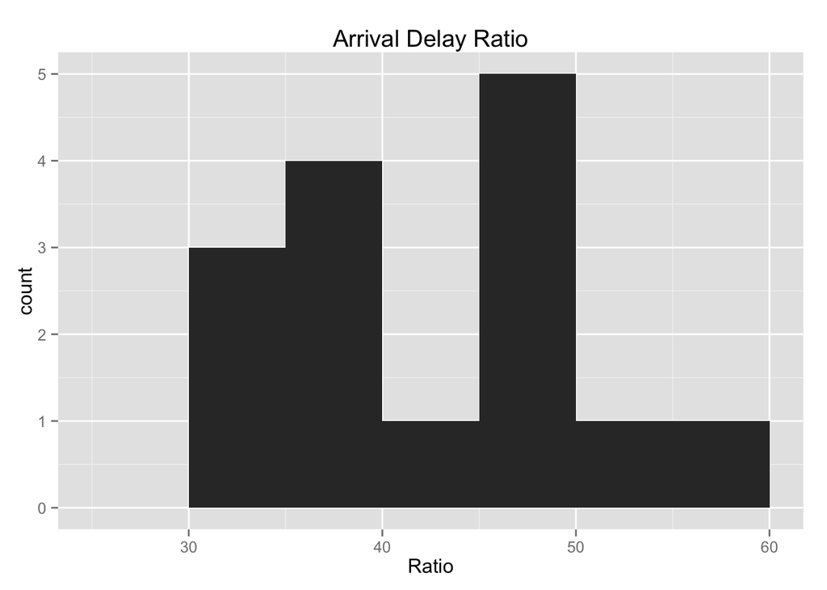

```r
ggplot(data=dd3) + geom_bar(aes(x=Ratio), bin=5) + ggtitle("Arrival Delay Ratio");
```